# 🍿🎥 Movie Revenue Analysis 🎬🌟

**Will Mizer**

This notebook covers exploratory data analysis, feature engineering, and modeling for box office revenue using the TMDB movie dataset.

# Part 1: Introduction

## Purpose

### Why This Project?

The movie industry represents one of the most financially unpredictable creative markets in the world. Studios routinely invest hundreds of millions of dollars into films with no guarantee of return — and yet, certain patterns in production budgets, talent, genre, and timing consistently separate box office successes from underperformers. This project investigates whether those patterns are quantifiable enough to predict revenue before a film is released.

### Goals

The primary goal of this project is to build a set of regression models capable of predicting a movie's box office revenue using only information available before release day — budget, genre, cast, director, production company, release timing, and franchise status. A secondary goal is to understand *which* of those pre-release signals carry the most predictive weight.

### Questions This Project Aims to Answer

1. How well can pre-release metadata alone predict box office revenue?
2. Which features — budget, genre, talent, or timing — are the strongest revenue predictors?
3. Do more complex models (XGBoost, Random Forest) outperform simpler linear models (Ridge, Lasso) on this task, or does thoughtful feature engineering level the playing field?
4. How much does temporal drift affect model performance when trained on historical films and evaluated on recent ones?

### Why Does This Matter?

Accurate revenue forecasting has real-world value across the film industry:

- **Studios and investors** use financial projections to greenlight productions, allocate marketing budgets, and manage portfolio risk across a slate of films
- **Streaming platforms** (Netflix, Disney+, Amazon) use revenue signals to prioritize acquisition and original content spending
- **Insurance underwriters** in the entertainment industry use financial models to price completion bonds and distribution guarantees
- **Researchers and analysts** studying cultural economics benefit from understanding what structural factors drive commercial performance

Even a model that explains 40–50% of revenue variance provides meaningful signal in an industry where gut instinct and star power often dominate decision-making. Understanding where the model *fails* — on low-budget overperformers and mega-blockbusters — is equally informative for understanding the limits of data-driven forecasting in creative industries.

## Summary

### Project Overview

This project applies exploratory data analysis, feature engineering, and supervised regression modeling to a dataset of 29,051 films sourced from the TMDB (The Movie Database) API. The central task is predicting box office revenue using only pre-release information — what a production team would realistically know before opening weekend.

### The Data

The raw dataset contains 29,051 films with 34 features covering production budgets, genres, cast and crew, release dates, production companies, spoken languages, franchise membership, and audience ratings. Financial data (budget and revenue) is severely incomplete: 62.76% of budget entries and 58.24% of revenue entries are zero, representing missing data rather than true zero-dollar films. Filtering to financially complete records reduces the usable dataset to **8,639 films**. Features were engineered from this filtered set including genre binary encodings, language dummies, production scale counts, release timing flags, budget tier bins, runtime deviation, and K-fold smoothed target encodings for director, cast, and production company.

### Approach

Four regression models were trained on a **chronological 80/20 split** (training: 1915–2017, test: 2017–2026) and evaluated on log-transformed revenue. The chronological split — rather than a random split — was used deliberately to simulate real-world deployment conditions and expose temporal drift. Models were evaluated using R², RMSE, and MAE on the held-out test set, with 5-fold cross-validation on the training set to monitor overfitting.

| Model | Test R² | RMSE | MAE |
| --- | --- | --- | --- |
| Ridge Regression | **0.461** | 1.914 | 1.293 |
| XGBoost | 0.452 | 1.929 | 1.272 |
| Random Forest | 0.438 | 1.954 | 1.301 |
| Lasso Regression | 0.437 | 1.956 | 1.314 |

### Key Findings

Ridge Regression was the top-performing model at **R² = 0.461**, slightly outperforming XGBoost (0.452). All four models converged in a narrow 0.024 R² band, indicating a genuine ceiling in the feature set rather than large differences in model quality. The dominant predictors across all models were **log_budget**, **director_avg_rev**, **actor_avg_rev**, and **prod_avg_rev** — the smoothed target-encoded entity features. The chronological test revealed consistent temporal drift: CV R² (~0.48–0.50) outperformed test R² (~0.44–0.46) across all models, confirming that post-2017 box office dynamics differ meaningfully from historical patterns.

The central conclusion is that pre-release metadata alone explains approximately **46% of box office revenue variance**. The remaining 54% is driven by factors unavailable in this dataset — marketing spend, social media momentum, opening weekend competition, and critic sentiment. This is a meaningful result: it quantifies both the power and the limits of data-driven forecasting in the film industry.

# Part 2: The Data and Exploratory Data Analysis

## 1. Setup & Data Loading

```python
import pandas as pd
import numpy as np
import matplotlib.pyplot as plt
import seaborn as sns
from matplotlib.colors import LinearSegmentedColormap

from sklearn.model_selection import train_test_split, cross_val_score
from sklearn.linear_model import LinearRegression, Ridge, Lasso
from sklearn.ensemble import RandomForestRegressor, GradientBoostingRegressor
from sklearn.preprocessing import MultiLabelBinarizer
from sklearn.metrics import r2_score, mean_absolute_error, mean_squared_error
from xgboost import XGBRegressor

IMDB_GOLD = '#DBA506'
IMDB_LIGHT_GOLD = '#F2DB83'
IMDB_BLACK = '#000000'
IMDB_PALETTE = [IMDB_GOLD, IMDB_LIGHT_GOLD, IMDB_BLACK]
IMDB_CMAP = LinearSegmentedColormap.from_list(
    'imdb_cmap',
    [IMDB_BLACK, IMDB_LIGHT_GOLD, IMDB_GOLD]
)

sns.set_theme(style='whitegrid')
sns.set_palette(IMDB_PALETTE)

pd.set_option('display.max_columns', None)

df = pd.read_parquet('data/movies_cleaned.parquet')
df.head(3)
```

|  | belongs_to_collection | budget | genres | homepage | id | imdb_id | origin_country | original_language | original_title | overview | popularity | poster_path | production_companies | production_countries | release_date | revenue | runtime | spoken_languages | status | tagline | title | vote_average | vote_count | release_year | release_month | release_day | part_of_series | cast | director | … |
| --- | --- | --- | --- | --- | --- | --- | --- | --- | --- | --- | --- | --- | --- | --- | --- | --- | --- | --- | --- | --- | --- | --- | --- | --- | --- | --- | --- | --- | --- | --- |
| 0 | Aki Kaurismäki, Trilogía del proletariado | 0 | [Comedy, Drama, Romance, Crime] | N/A | 2 | tt0094675 | [FI] | other | Ariel | A Finnish man goes to the city to find a job a... | 2.4708 | /ojDg0PGvs6R9xYFodRct2kdI6wC.jpg | [Villealfa Filmproductions] | [Finland] | 1988-10-21 | 0 | 73 | [suomi] | Released |  | Ariel | 7.104 | 370 | 1988 | 10 | 21 | 1 | [Turo Pajala, Susanna Haavisto, Matti Pellonpä... | [Aki Kaurismäki] | … |
| 1 | Aki Kaurismäki, Trilogía del proletariado | 0 | [Comedy, Drama, Romance] | N/A | 3 | tt0092149 | [FI] | other | Varjoja paratiisissa | Nikander, a rubbish collector and would-be ent... | 1.9842 | /nj01hspawPof0mJmlgfjuLyJuRN.jpg | [Villealfa Filmproductions] | [Finland] | 1986-10-17 | 0 | 74 | [svenska, suomi, English] | Released |  | Shadows in Paradise | 7.300 | 435 | 1986 | 10 | 17 | 1 | [Matti Pellonpää, Kati Outinen, Sakari Kuosman... | [Aki Kaurismäki] | … |
| 2 |  | 4000000 | [Comedy] | https://www.miramax.com/movie/four-rooms/ | 5 | tt0113101 | [US] | en | Four Rooms | It's Ted the Bellhop's first night on the job.... | 3.0036 | /75aHn1NOYXh4M7L5shoeQ6NGykP.jpg | [Miramax, A Band Apart] | [United States of America] | 1995-12-09 | 4257354 | 98 | [English] | Released | Twelve outrageous guests. Four scandalous requ... | Four Rooms | 5.892 | 2809 | 1995 | 12 | 9 | 0 | [Tim Roth, Jennifer Beals, David Proval, Ione ... | [Alexandre Rockwell, Quentin Tarantino, Alliso... | … |

## 2. Data Source

The dataset was collected from the TMDB (The Movie Database) API. TMDB aggregates movie information including financials, cast, production data, and ratings, pulling heavily from IMDb and other film databases.

Because TMDB is an established, regularly updated industry source, the dataset can be considered trustworthy for exploratory analysis and modeling. However, it is important to note that:

- Some financial values (budget or revenue) may be missing
- Data accuracy and fullness varies across older films
- Non-US films are underrepresented in financial data

## 3. Dataset Dimensions

```python
print(f"Number of rows:    {df.shape[0]}")
print(f"Number of columns: {df.shape[1]}")
```

```
Number of rows:    29051
Number of columns: 34
```

The dataset contains **29,051 rows** and **34 columns**

## 4. Data Information - Variable Names, Types, and Meanings

```python
df.info()
```

```
<class 'pandas.DataFrame'>
RangeIndex: 29051 entries, 0 to 29050
Data columns (total 34 columns):
 #   Column                 Non-Null Count  Dtype
---  ------                 --------------  -----
 0   belongs_to_collection  29051 non-null  str
 1   budget                 29051 non-null  int64
 2   genres                 29051 non-null  object
 3   homepage               29051 non-null  str
 4   id                     29051 non-null  int64
 5   imdb_id                29033 non-null  str
 6   origin_country         29051 non-null  object
 7   original_language      29051 non-null  str
 8   original_title         29051 non-null  str
 9   overview               29051 non-null  str
```

[output cut: 26 more lines]

The dataset is largely complete - nearly all 34 columns have 29,051 non-null entries. The two exceptions are `imdb_id` (29,033 non-null, missing ~18 entries) and `poster_path` (29,050 non-null, missing 1). All financial columns (`budget`, `revenue`, `profit`) are fully populated as integers.

### Feature Dictionary

| Column | Description | Data Type |
| --- | --- | --- |
| belongs_to_collection | Name of the movie franchise or collection the film belongs to | Categorical |
| budget | Production budget of the film (USD) | Numerical |
| genres | List of genres associated with the film | Categorical |
| homepage | Official website for the movie | Categorical |
| id | Unique TMDB identifier for the movie | Numerical |
| imdb_id | IMDb identifier used to link the movie to IMDb | Categorical |
| origin_country | Country where the movie was originally produced | Categorical |
| original_language | Original language the movie was released in | Categorical |
| original_title | Original title of the movie | Categorical |
| overview | Short plot summary of the movie | Text |
| popularity | Popularity score provided by TMDB | Numerical |
| poster_path | Path to the movie poster image | Categorical |
| production_companies | List of companies involved in producing the movie | Categorical |
| production_countries | Countries where the movie was produced | Categorical |
| release_date | Official release date of the movie | Date |
| revenue | Total box office revenue generated by the movie (USD) | Numerical |
| runtime | Length of the movie in minutes | Numerical |
| spoken_languages | Languages spoken in the movie | Categorical |
| status | Production or release status of the movie | Categorical |
| tagline | Marketing tagline associated with the movie | Text |
| title | Title of the movie | Categorical |
| vote_average | Average user rating for the movie | Numerical |
| vote_count | Total number of user votes received | Numerical |
| release_year | Year the movie was released | Numerical |
| release_month | Month the movie was released | Numerical |
| release_day | Day of the month the movie was released | Numerical |
| cast | List of main actors appearing in the movie | Categorical |
| director | Director(s) of the movie | Categorical |
| writer | Writer(s) of the movie | Categorical |
| composer | Composer(s) responsible for the movie soundtrack | Categorical |
| cinematographer | Cinematographer(s) responsible for filming | Categorical |
| producer | Producer(s) responsible for the movie | Categorical |
| profit | Profit calculated as revenue minus budget | Numerical |

## 5. Summary Statistics

```python
df.describe()
```

|  | budget | id | popularity | release_date | revenue | runtime | vote_average | vote_count | release_year | release_month | release_day | part_of_series | profit |
| --- | --- | --- | --- | --- | --- | --- | --- | --- | --- | --- | --- | --- | --- |
| count | 2.905100e+04 | 2.905100e+04 | 29051.000000 | 29051 | 2.905100e+04 | 29051.000000 | 29051.000000 | 29051.000000 | 29051.0 | 29051.0 | 29051.0 | 29051.000000 | 2.905100e+04 |
| mean | 9.255437e+06 | 2.780337e+05 | 2.148133 | 2003-07-11 19:55:34.811194112 | 2.617012e+07 | 103.306943 | 6.316578 | 782.930708 | 2002.995904 | 6.895666 | 15.439262 | 0.188014 | 1.691468e+07 |
| min | 0.000000e+00 | 2.000000e+00 | 0.033600 | 1913-11-26 00:00:00 | 0.000000e+00 | 46.000000 | 1.484000 | 26.000000 | 1913.0 | 1.0 | 1.0 | 0.000000 | -3.200000e+08 |
| 25% | 0.000000e+00 | 2.381050e+04 | 0.783550 | 1994-08-05 00:00:00 | 0.000000e+00 | 90.000000 | 5.790500 | 49.000000 | 1994.0 | 4.0 | 8.0 | 0.000000 | 0.000000e+00 |
| 50% | 0.000000e+00 | 8.176000e+04 | 1.354000 | 2010-03-19 00:00:00 | 0.000000e+00 | 100.000000 | 6.396000 | 127.000000 | 2010.0 | 7.0 | 15.0 | 0.000000 | 0.000000e+00 |
| 75% | 5.000000e+06 | 4.604615e+05 | 2.385300 | 2018-03-23 00:00:00 | 6.911613e+06 | 113.000000 | 6.955000 | 507.000000 | 2018.0 | 10.0 | 23.0 | 0.000000 | 1.546572e+06 |
| max | 4.899000e+08 | 1.610413e+06 | 200.130600 | 2026-01-14 00:00:00 | 2.923706e+09 | 270.000000 | 9.667000 | 39148.000000 | 2026.0 | 12.0 | 31.0 | 1.000000 | 2.686706e+09 |
| std | 2.650606e+07 | 3.429586e+05 | 3.776286 | NaN | 1.026149e+08 | 21.017442 | 0.914484 | 2177.549334 | 20.295044 | 3.460725 | 8.802033 | 0.390730 | 8.477694e+07 |

**Summary Statistics Interpretation:**

Patterns that stand out from the numerical summary statistics:

**Budget:** Most movies have relatively small budgets, with the 75th percentile at $5M. The maximum is $489M, indicating a small number of blockbuster films that create strong right skew.

**Revenue and Profit:** Both show very large ranges. The median revenue is zero - confirming that more than half of all films in the dataset have no reported revenue. The maximum revenue exceeds $2.9 billion, driven entirely by a handful of blockbusters.

**Popularity:** The mean is 2.15 and the maximum is 200.1. The large gap between the mean and max confirms this metric is dominated by a small number of highly trending or recently released films, with the vast majority of films clustering near the lower end.

**Runtime:** Films range from 46 to 270 minutes. The IQR (90–113 min) aligns with typical feature-length films, and the mean of 103 minutes is consistent with industry norms.

**Vote Average:** Ratings cluster around 6.3, with most films between 5.8 and 7.0. The maximum of 9.667 likely represents well-received niche films with fewer but highly positive ratings.

**Vote Count:** Ranges from 26 to 39,148. The mean of 783 and the large standard deviation (2,178) confirm that audience engagement is heavily concentrated among a small number of popular films.

## 6. Distributions of Continuous Variables

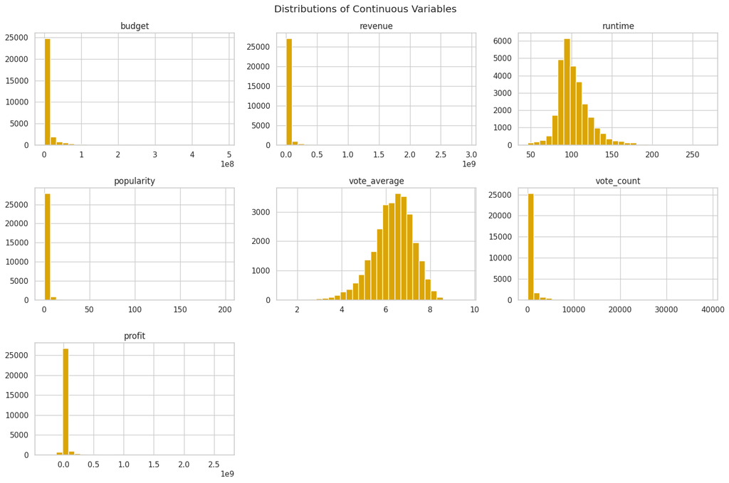

```python
continuous_vars = [
    'budget', 'revenue', 'runtime', 'popularity',
    'vote_average', 'vote_count', 'profit'
]

df[continuous_vars].hist(bins=30, figsize=(15, 10))
plt.suptitle('Distributions of Continuous Variables')
plt.tight_layout()
plt.show()
```

**Histogram Interpretation:**

Budget, revenue, profit, popularity, and vote_count are all heavily right-skewed - the vast majority of observations cluster near zero with a long tail of high-value outliers. These represent a genuine split between low-profile films and a small number of blockbusters that dominate the financial upper end. (Something that seems to be a huge trend within this dataset)

Vote average is the most normally distributed of the group, centered around 6.3 with relatively little spread. Runtime is also fairly symmetric with the bulk of films between 90 and 120 minutes.

The skewness of the financial variables has direct implications for modeling: standard linear regression will be heavily skewed by blockbuster outliers. Log-transforming budget and revenue before modeling will be crucial to reduce this effect and stabilize predictions.

## 7. Missing / Zero Value Analysis

```python
for col in continuous_vars:
    zero_count = (df[col] == 0).sum()
    total_count = df[col].shape[0]
    percentage_zero = (zero_count / total_count) * 100
    if percentage_zero != 0:
        print(f"{col}: {percentage_zero:.2f}% of entries are 0")
```

```
budget: 62.76% of entries are 0
revenue: 58.24% of entries are 0
profit: 50.77% of entries are 0
```

**Zero Value Interpretation:**

62.76% of budget entries and 58.24% of revenue entries are zero - these represent missing financial data, not actual zero-dollar films. This is the single largest data quality issue in the dataset. Profit inherits this problem since it is derived directly from both columns (50.77% zeros).

Any model trained on rows where budget or revenue is zero would be learning from effectively missing data. This is why the feature engineering section filters to only rows where both budget and revenue are greater than zero, reducing the dataset from ~29,000 to ~8,600 records. The tradeoff is significant - we lose about 70% of rows but trying to fit missing data accurately is a very difficut task and this ensures that we are working with accurate, verified movie data.

## 8. Categorical Variable Exploration

```python
categorical_vars = ['original_language', 'release_year', 'belongs_to_collection']

for col in categorical_vars:
    print(f"\nTop values for {col}")
    print(df[col].value_counts().head(10))
```

```
Top values for original_language
original_language
en       17529
fr        2043
ja        1779
it        1055
es         989
other      885
ko         794
zh         617
ru         587
de         533
Name: count, dtype: int64

Top values for release_year
release_year
2018    1141
2017    1111
2019    1102
2022     987
2016     984
2015     975
2014     957
2023     949
2021     916
2024     872
Name: count, dtype: Int64

Top values for belongs_to_collection
belongs_to_collection
                                            23589
Doraemon Movies                                41
Detective Conan Collection                     28
James Bond Collection                          26
Zatoichi: The Blind Swordsman Collection       26
Lupin the Third Collection                     25
Crayon Shin-chan Collection                    21
Maneater Collection                            17
Godzilla (Showa) Collection                    14
One Piece Collection                           14
Name: count, dtype: int64
```

**Categorical Feature Interpretation:**

English dominates the dataset at ~17,500 films. French (2,043) and Japanese (1,779) are the next most represented, followed by Italian, Spanish, and Korean. The remaining languages are grouped into an "other" category of ~885 entries. This heavy skew toward English means language-based features will have limited discriminatory power - most films will share the same `lang_en=1` encoding.

Release year counts peak in the mid-2010s to early 2020s, with 2018 leading at 1,141 films. This concentration in recent years is expected - TMDB has better data coverage for modern films. It also means the dataset is more representative of contemporary filmmaking patterns than historical ones.

The majority of films (~23,589) do not belong to any collection. The most represented collections are long-running animation franchises and classic action series. The franchise flag will be a useful predictor.

## 9. Top Cast, Directors, and Crew

```python
creative_cols = ['cast', 'director', 'writer', 'composer',
                 'cinematographer', 'producer', 'production_companies', 'production_countries']

for col in creative_cols:
    print(f"\n--- Top 10 in {col.upper()} ---")
    top_names = df[col].explode().value_counts().head(10)
    print(top_names)
```

```
--- Top 10 in CAST ---
cast
Samuel L. Jackson    101
Nicolas Cage         100
Bruce Willis          99
Jackie Chan           94
Robert De Niro        91
Willem Dafoe          82
Frank Welker          81
Michael Caine         80
Morgan Freeman        79
Liam Neeson           76
Name: count, dtype: int64

--- Top 10 in DIRECTOR ---
director
Takashi Miike        44
Woody Allen          40
Alfred Hitchcock     39
Clint Eastwood       38
Steven Spielberg     35
Steven Soderbergh    33
Tsui Hark            32
John Ford            30
Ridley Scott         29
Johnnie To           29
Name: count, dtype: int64

--- Top 10 in WRITER ---
writer
Luc Besson            48
Wong Jing             42
Woody Allen           41
Tsui Hark             31
Piero De Bernardi     30
Furio Scarpelli       30
John Hughes           29
Tyler Perry           29
David Koepp           28
Leonardo Benvenuti    28
```

[output cut: 56 more lines]

```
Name: count, dtype: int64

--- Top 10 in PRODUCTION_COUNTRIES ---
production_countries
United States of America    14854
France                       3367
United Kingdom               3367
Japan                        2026
Italy                        1648
Canada                       1631
Germany                      1620
India                         928
South Korea                   880
Spain                         810
Name: count, dtype: int64
```

**Interpretation:**

Samuel L. Jackson (101), Nicolas Cage (100), and Bruce Willis (99) top the cast list. Among directors, Takashi Miike leads with 44 films, reflecting Japan's high-output commercial film industry. Steven Spielberg and Clint Eastwood represent the US studio system with 35 and 38 films respectively.

Hans Zimmer leads composers at 135 films, consistent with his status as the most in-demand Hollywood composer of the past 30 years. Among producers, David Michael Latt (110) and Jason Blum (104) top the list - both associated with low-to-mid budget genre films, which explains their high output.

## 10. Release Timing Patterns

```python
df['release_date'] = pd.to_datetime(df['release_date'], errors='coerce')
df['release_month'] = df['release_date'].dt.month
df['release_day_of_week'] = df['release_date'].dt.day_name()

print("--- Top Release Months ---")
print(df['release_month'].value_counts().head(10))

print("\n--- Top Release Days of Week ---")
print(df['release_day_of_week'].value_counts().head(10))
```

```
--- Top Release Months ---
release_month
10    3175
9     3060
12    2811
11    2530
8     2437
3     2430
4     2252
6     2144
2     2102
5     2070
Name: count, dtype: int64

--- Top Release Days of Week ---
release_day_of_week
Friday       10038
Thursday      5986
Wednesday     5318
Saturday      2862
Tuesday       2136
Monday        1381
Sunday        1330
Name: count, dtype: int64
```

**Release Timing Interpretation:**

October leads in release count (3,175), followed by September (3,060) and December (2,811). These fall months align with award season positioning and early holiday scheduling. The summer months are somewhat lower by count, but studios typically concentrate their highest-grossing releases in that window — meaning fewer films but larger individual performances.

Friday is by far the most common release day at 10,038 films - nearly double the next highest day (Thursday at 5,986). This is consistent with the US theatrical release convention of wide openings on Fridays. This pattern directly motivates the `is_friday_release` flag created in the feature engineering section.

## 11. Top Genres

```
--- Top 10 Genres ---
genres
Drama              13418
Comedy              9544
Thriller            6703
Action              5850
Romance             5191
Horror              4382
Crime               4079
Adventure           3473
Science Fiction     2656
Fantasy             2619
Name: count, dtype: int64
```

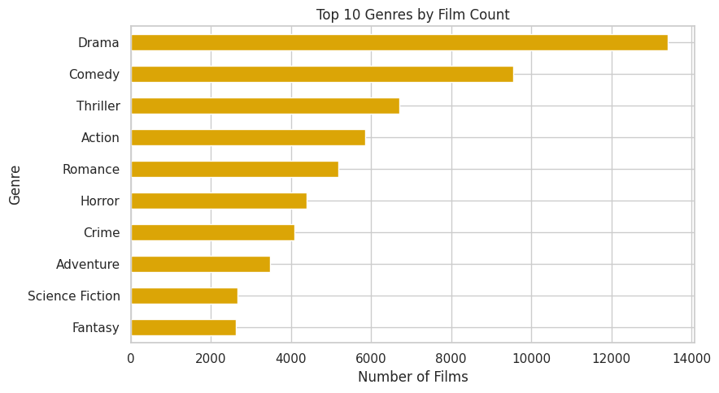

```python
print("--- Top 10 Genres ---")
top_genres = df['genres'].explode().value_counts().head(10)
print(top_genres)

plt.figure(figsize=(9, 5))
top_genres.sort_values().plot(kind='barh', color=IMDB_GOLD)
plt.title('Top 10 Genres by Film Count')
plt.xlabel('Number of Films')
plt.ylabel('Genre')                    # ← this line is the fix
plt.tight_layout()
plt.show()
```

**Genre Interpretation:**

Drama (13,418) and Comedy (9,544) dominate by raw count, reflecting how broadly those labels are applied across the industry. Thriller (6,703), Action (5,850), and Romance (5,191) follow. Science Fiction (2,656) and Fantasy (2,619) are less frequent but tend to be associated with higher-budget productions - making their genre flags potentially valuable predictors of revenue despite lower counts.

Since many films carry multiple genre labels, these counts overlap significantly. One-hot encoding genres in the feature engineering section allows each genre to be treated as an independent binary signal rather than requiring a single category assignment.

## 12. Correlation Heatmap

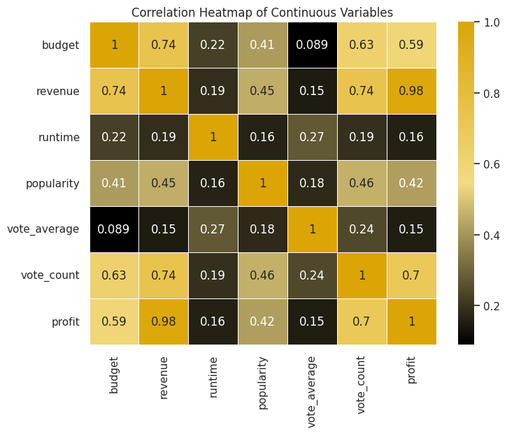

```python
plt.figure(figsize=(8, 6))
sns.heatmap(df[continuous_vars].corr(), annot=True, cmap=IMDB_CMAP, linewidths=0.5)
plt.title('Correlation Heatmap of Continuous Variables')
plt.show()
```

**Correlation Heatmap Interpretation:**

The relatively weak correlations among most pairs confirm that multicollinearity is not a major concern for the raw continuous variables. However, the budget tier dummies and log transformations applied in the modeling section will change these relationships substantially.

## 13. Average Budget by Release Year

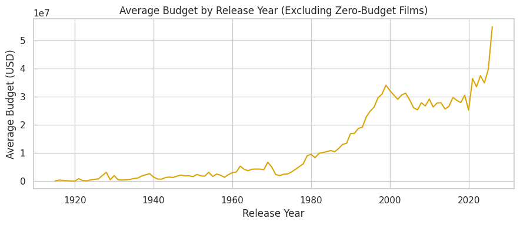

```python
avg_budget_by_year = df[df['budget'] != 0].groupby('release_year')['budget'].mean().reset_index()

plt.figure(figsize=(9, 4))
sns.lineplot(data=avg_budget_by_year, x='release_year', y='budget')
plt.title('Average Budget by Release Year (Excluding Zero-Budget Films)')
plt.xlabel('Release Year')
plt.ylabel('Average Budget (USD)')
plt.tight_layout()
plt.show()
```

**Budget Trend Interpretation:**

Average production budgets have risen substantially over time, with a sharp increase visible from the 1980s onward. This trend reflects a combination of inflation, the maturation of the blockbuster model, and escalating costs in visual effects and global marketing. The trend is not perfectly linear - there are notable spikes during spending eras and dips that correspond to economic downturns.

This trend is directly relevant to the modeling section: a $10M budget film from 1990 and a $10M budget film from 2020 represent very different production scales relative to their eras. The models treat these identically in nominal terms, which is a known limitation. Doing the time split later for test/train combats this problem slightly.

## 14. Budget vs. Revenue Scatter (Films with Reported Financials)

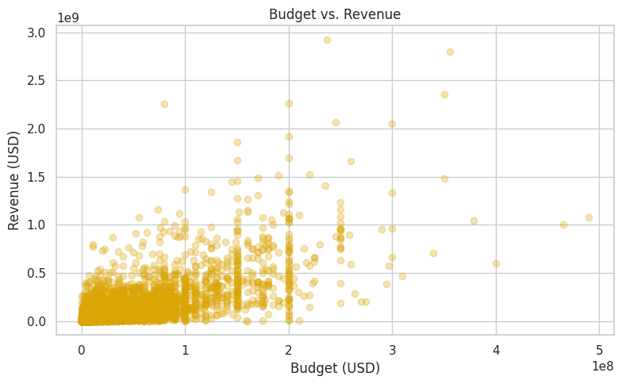

```python
df_financials = df[(df['budget'] > 0) & (df['revenue'] > 0)]

plt.figure(figsize=(8, 5))
plt.scatter(df_financials['budget'], df_financials['revenue'], alpha=0.3, color=IMDB_GOLD)
plt.title('Budget vs. Revenue')
plt.xlabel('Budget (USD)')
plt.ylabel('Revenue (USD)')
plt.tight_layout()
plt.show()
```

**Budget-Revenue Relationship Interpretation:**

There is a clear positive relationship between budget and revenue among the 8,639 films with complete financial data, but with enormous spread at every budget level. The relationship is non-linear - a film with a $100M budget does not reliably earn twice what a $50M film earns. A small cluster of very high-budget films occupies the upper right of the plot, and several high-revenue films were produced at relatively modest budgets.

## 15. EDA Summary — What We Learned

The exploratory analysis revealed several key findings that helped structure the modeling approach:

**Financial data is severely incomplete.** 62.76% of budget entries and 58.24% of revenue entries are zero, representing missing data rather than actual values. Filtering to complete-financial-data films reduces the usable dataset from 29,051 to 8,639 records.

**Financial variables are extremely right-skewed.** Budget, revenue, and profit are dominated by a small number of blockbuster films. Log-transforming these variables before modeling is essential to prevent outliers from distorting predictions.

**Budget is the strongest single predictor of revenue**, but the budget-revenue scatter shows enormous variance at every budget level - other factors contribute substantially and must be engineered as features.

**Release timing carries signal.** Friday is by far the most common wide-release day (10,038 films), and fall/holiday months are peak release periods. These patterns are encoded as explicit binary flags in the feature engineering section.

**The dataset has a strong US/English bias.** English accounts for ~60% of all films; the US is listed as a production country for ~77% of financially complete records. This limits the diversity of non-US signal available to models.

**Franchise membership is rare but meaningful.** Only ~25% of financially complete films belong to a collection, but those films tend to be higher-budget and higher-revenue — making `part_of_series` a strong feature candidate.

**Leakage variables must be dropped.** `profit` (derived from revenue), `vote_count`, and `vote_average` (only available post-release) cannot be used as predictors in a realistic pre-release prediction task.

# Part 3: Feature Engineering & Modeling

## 16. Initial Cleaning for Modeling

Drop columns that are not useful for modeling and filter to only movies with both a budget and revenue reported. This drops from ~29,000 to ~8,600 usable records - a significant reduction, but necessary to avoid training on effectively missing data.

```python
print(f"Rows before filtering: {len(df)}")

drop_cols = ['id', 'imdb_id', 'original_title', 'overview', 'tagline',
             'poster_path', 'homepage', 'status', 'release_date', 'popularity']
df.drop(columns=drop_cols, inplace=True)

df = df[(df['budget'] > 0) & (df['revenue'] > 0)]

print(f"Rows after filtering:  {len(df)}")
print(f"Columns remaining:     {len(df.columns)}")
```

```
Rows before filtering: 29051
Rows after filtering:  8639
Columns remaining:     25
```

After dropping 10 non-informative columns and filtering to financially complete films, the dataset reduces from 29,051 rows to **8,639 rows** with 25 columns. The 10 dropped columns include identifiers (`id`, `imdb_id`), free-text fields (`overview`, `tagline`), and metadata not relevant to modeling (`poster_path`, `homepage`, `status`, `release_date`, `popularity`).

## 17. Feature Engineering

This section creates new features from the existing data to give the models more signal.

### 17.1 Genre Encoding

Genres are stored as a list per movie. MultiLabelBinarizer was used to one-hot encode each genre into its own binary column.

```python
mlb = MultiLabelBinarizer()
genre_encoded = mlb.fit_transform(df['genres'])
genre_df = pd.DataFrame(genre_encoded, columns=mlb.classes_, index=df.index)

df = pd.concat([df, genre_df], axis=1)
df.drop('genres', axis=1, inplace=True)

print(f"Genres encoded: {list(mlb.classes_)}")
```

```
Genres encoded: ['Action', 'Adventure', 'Animation', 'Comedy', 'Crime', 'Documentary', 'Drama', 'Family', 'Fantasy', 'History', 'Horror', 'Music', 'Mystery', 'Romance', 'Science Fiction', 'TV Movie', 'Thriller', 'War', 'Western']
```

19 genre binary columns are added, one for each unique genre in the dataset. Each film can have multiple genres set to 1. This replaces the single list column with a sparse binary matrix that models can use directly.

### 17.2 Language Encoding

Original language is encoded using `pd.get_dummies`. Languages with fewer than 50 entries in the filtered dataset are grouped into `lang_other` to avoid excessive sparsity.

```python
lang_counts = df['original_language'].value_counts()
rare_langs = lang_counts[lang_counts < 50].index
df['original_language'] = df['original_language'].replace(rare_langs, 'other')

df = pd.get_dummies(df, columns=['original_language'], prefix='lang', dtype=int)
print(f"Language columns added. Total columns: {len(df.columns)}")
```

```
Language columns added. Total columns: 53
```

11 language dummy columns are added (cn, en, es, fr, hi, it, ja, ko, other, ru, zh). Rare languages are collapsed into `lang_other` to prevent adding dozens of near-empty columns that would add noise without signal. Total column count rises to 53.

### 17.3 Production Scale Features

Instead of encoding individual names (which would create thousands of sparse columns), only broad production-scale signals are retained. Larger producer and production-company counts may indicate bigger-budget productions.

```python
df['producer_count']       = df['producer'].apply(len)
df['production_co_count']  = df['production_companies'].apply(len)

print("Production scale features created:")
print(df[['producer_count', 'production_co_count']].describe().round(2))
```

```
Production scale features created:
       producer_count  production_co_count
count         8639.00              8639.00
mean             2.65                 3.41
std              1.71                 2.17
min              0.00                 0.00
25%              1.00                 2.00
50%              2.00                 3.00
75%              3.00                 4.00
max             29.00                24.00
```

`producer_count` averages 2.65 (range: 0-29) and `production_co_count` averages 3.41 (range: 0-24). Both have meaningful variance and loosely capture production scale. Other crew count features - cast_count, director_count, and composer_count - were excluded because cast is capped at 10, and director/composer counts are almost always 1 with little variance.

### 17.4 Collection / Franchise Flag

Movies that belong to a franchise or collection tend to have built-in audiences and higher revenues. This is encoded as a binary part_of_series flag.

```python
df['part_of_series'] = (df['belongs_to_collection'].str.strip() != '').astype(int)
print(f"Movies in a collection: {df['part_of_series'].sum()} ({df['part_of_series'].mean()*100:.1f}%)")
```

```
Movies in a collection: 2184 (25.3%)
```

2,184 of the 8,639 financially complete films (25.3%) belong to a collection or franchise. This is expected to be a strong predictor - franchise films generally have pre-sold audiences and larger marketing budgets, both of which directly impact box office revenue.

### 17.5 Release Timing Flags

Summer and Holidays are historically the strongest box office periods. Binary flags for these two windows rather than adding broad season dummies that would partially overlap with them.

```python
df['is_summer_release']  = df['release_month'].isin([6, 7, 8]).astype(int)
df['is_holiday_release'] = df['release_month'].isin([11, 12]).astype(int)

print("Season timing flags created.")
print(df[['is_summer_release', 'is_holiday_release']].sum())
```

```
Season timing flags created.
is_summer_release     2138
is_holiday_release    1644
dtype: int64
```

2,138 films (24.7%) were released in the summer window and 1,644 (19.0%) during the holiday season. These two windows together cover approximately 44% of the dataset. Since studios deliberately schedule their most commercially ambitious films in these periods, the flags should carry signal past what pure `release_month` alone provides.

### 17.6 US Production Flag

US-produced films tend to have larger marketing budgets and wider global distribution. A binary flag indicates whether the United States is listed among the production countries.

```python
df['is_us_production'] = df['production_countries'].apply(
    lambda x: int('United States of America' in x)
)
print(f"US productions: {df['is_us_production'].sum()} ({df['is_us_production'].mean()*100:.1f}%)")
```

```
US productions: 6654 (77.0%)
```

6,654 of 8,639 films (77.0%) are US productions. This heavy skew toward 1 limits the flag's marginal contribution as a standalone linear predictor, but it may still interact usefully with budget and genre features in tree-based models. The high rate also reflects a known dataset bias: non-US films are less likely to have complete financial data reported on TMDB.

### 17.7 Budget Tier Feature

The budget is binned into four tiers (micro, low, mid, blockbuster) based on natural breakpoints in the data. This captures the non-linear relationship between budget and revenue - a $200M blockbuster operates very differently from a $1M indie film.

```python
budget_bins   = [0, 1_000_000, 10_000_000, 50_000_000, float('inf')]
budget_labels = ['micro', 'low', 'mid', 'blockbuster']

df['budget_tier'] = pd.cut(df['budget'], bins=budget_bins, labels=budget_labels)
df = pd.get_dummies(df, columns=['budget_tier'], prefix='tier', dtype=int)

print("Budget tier distribution:")
print(df[['tier_micro', 'tier_low', 'tier_mid', 'tier_blockbuster']].sum())
```

```
Budget tier distribution:
tier_micro           663
tier_low            2932
tier_mid            3669
tier_blockbuster    1375
dtype: int64
```

The distribution shows 663 micro-budget films (under $1M), 2,932 low-budget ($1M-$10M), 3,669 mid-budget ($10M–$50M), and 1,375 blockbusters (over $50M). The mid tier is the largest, reflecting the concentration of studio releases in the $10M-$50M range.

### 17.8 Friday Release Flag

The EDA showed that Friday is by far the most common release day. A Friday release signals studio confidence in wide theatrical distribution.

```python
df['release_dow'] = pd.to_datetime(
    df[['release_year', 'release_month', 'release_day']].rename(
        columns={'release_year': 'year', 'release_month': 'month', 'release_day': 'day'}
    )
).dt.dayofweek

df['is_friday_release'] = (df['release_dow'] == 4).astype(int)
print(f"Friday releases: {df['is_friday_release'].sum()} ({df['is_friday_release'].mean()*100:.1f}%)")
```

```
Friday releases: 3608 (41.8%)
```

3,608 of 8,639 films (41.8%) were released on a Friday, consistent with the EDA finding. This is a reasonable proxy for wide theatrical release - studios reserve Friday openings for films they expect to perform well, which correlates with higher budgets and wider distribution.

### 17.9 Runtime Deviation Feature

Rather than using raw runtime, runtime deviation is calculated as the absolute difference. Films that are much longer or shorter than average may signal unusual production types.

```python
median_runtime = df['runtime'].median()
df['runtime_deviation'] = (df['runtime'] - median_runtime).abs()
print(f"Median runtime: {median_runtime} min")
print(f"Mean absolute deviation from median: {df['runtime_deviation'].mean():.1f} min")
```

```
Median runtime: 106.0 min
Mean absolute deviation from median: 15.7 min
```

The median runtime across films is 106 minutes, with an average absolute deviation of 15.7 minutes. Films deviating significantly from this norm - very short films or very long prestige epics - often have different revenue profiles than standard feature-length films. Encoding deviation rather than raw runtime centers the feature around zero and makes the effect more interpretable.

### 17.10 Feature Engineering Summary

```python
engineered_features = [
    'producer_count', 'production_co_count', 'part_of_series',
    'is_summer_release', 'is_holiday_release', 'is_us_production',
    'is_friday_release', 'runtime_deviation',
    'tier_micro', 'tier_low', 'tier_mid', 'tier_blockbuster'
]

print(f"Engineered features ({len(engineered_features)}):")
for f in engineered_features:
    print(f"  - {f}")

print(f"\nTotal dataframe columns: {len(df.columns)}")
```

```
Engineered features (12):
  - producer_count
  - production_co_count
  - part_of_series
  - is_summer_release
  - is_holiday_release
  - is_us_production
  - is_friday_release
  - runtime_deviation
  - tier_micro
  - tier_low
  - tier_mid
  - tier_blockbuster

Total dataframe columns: 65
```

12 new features were engineered. Combined with the 19 genre dummies, 11 language dummies, and base numerical features, the total dataframe reaches 65 columns at this stage. The modeling step will reduce this further by dropping remaining string columns and leakage variables.

## 18. Prepare Modeling Dataset

Drop all remaining non-numeric or leakage columns and apply log transforms to the heavily skewed financial variables.

**Leakage note:** `profit`, `vote_average`, and `vote_count` are dropped because they are either derived from revenue or only available after a film is released - they would not be known at prediction time. `release_day_of_week` is also dropped as it was only needed to derive `is_friday_release`.

```python
drop_for_model = [
    'title', 'cast', 'director', 'writer', 'composer', 'cinematographer',
    'producer', 'production_companies', 'belongs_to_collection',
    'origin_country', 'production_countries', 'spoken_languages',
    'vote_average', 'vote_count', 'profit', 'release_dow', 'release_day_of_week'
]

df_model = df.drop(columns=drop_for_model, errors='ignore').copy()

# remove any unexpected non-numeric columns before modeling
non_numeric_cols = df_model.select_dtypes(exclude=[np.number]).columns.tolist()
if non_numeric_cols:
    print(f"Dropping non-numeric columns: {non_numeric_cols}")
    df_model.drop(columns=non_numeric_cols, inplace=True)

df_model['log_revenue'] = np.log(df_model['revenue'])
df_model['log_budget']  = np.log(df_model['budget'])
df_model.drop(columns=['revenue', 'budget'], inplace=True)

print(f"Modeling dataset: {df_model.shape[0]} rows x {df_model.shape[1]} columns")
df_model.info()
```

```
Modeling dataset: 8639 rows x 48 columns
<class 'pandas.DataFrame'>
Index: 8639 entries, 2 to 29041
Data columns (total 48 columns):
 #   Column               Non-Null Count  Dtype
---  ------               --------------  -----
 0   runtime              8639 non-null   int64
 1   release_year         8639 non-null   Int64
 2   release_month        8639 non-null   int32
 3   release_day          8639 non-null   Int64
 4   part_of_series       8639 non-null   int64
 5   Action               8639 non-null   int64
 6   Adventure            8639 non-null   int64
 7   Animation            8639 non-null   int64
 8   Comedy               8639 non-null   int64
```

[output cut: 41 more lines]

## 19. Train/Test Split

A chronological split was used rather than a random split. Movies are sorted by release year and the oldest 80% form the training set, with the most recent 20% held out for testing. This is more realistic than a random split - a model predicting revenue would always be trained on historical data and evaluated on future films. It also reveals temporal drift: if performance degrades meaningfully on newer films, that signals the patterns are shifting over time.

```python
X = df_model.drop('log_revenue', axis=1)
y = df_model['log_revenue']

valid_year_mask = X['release_year'].notna()
X = X.loc[valid_year_mask].copy()
y = y.loc[valid_year_mask].copy()

X_sorted = X.sort_values(['release_year'], kind='mergesort')
y_sorted = y.loc[X_sorted.index]

n_total = len(X_sorted)
n_test  = int(round(n_total * 0.20))
n_train = n_total - n_test

X_train = X_sorted.iloc[:n_train].copy()
X_test  = X_sorted.iloc[n_train:].copy()
y_train = y_sorted.iloc[:n_train].copy()
y_test  = y_sorted.iloc[n_train:].copy()

train_pct = (len(X_train) / n_total) * 100
test_pct  = (len(X_test)  / n_total) * 100

print(f"Training set:   {X_train.shape[0]} samples ({train_pct:.2f}%)")
print(f"Test set:       {X_test.shape[0]} samples ({test_pct:.2f}%)")
print(f"Feature count:  {X_train.shape[1]} features")
print(f"Train years:    {int(X_train['release_year'].min())}\u2013{int(X_train['release_year'].max())}")
print(f"Test years:     {int(X_test['release_year'].min())}\u2013{int(X_test['release_year'].max())}")
```

```
Training set:   6911 samples (80.00%)
Test set:       1728 samples (20.00%)
Feature count:  47 features
Train years:    1915–2017
Test years:     2017–2026
```

## 20. K-Fold Smoothed Target Encoding

Director, cast, and production company names are encoded using **smoothed target encoding with out-of-fold (OOF) estimation**. Rather than one-hot encoding each name - which would add thousands of columns - Each entity was replaced with its historically observed average log revenue, smoothed toward the global mean to prevent overfitting on rare entities.

OOF encoding is used on the training set to prevent leakage: each row's encoded value is computed only from the folds that exclude that row. The full training set maps are then applied to the test set.

```python
from sklearn.model_selection import KFold

def normalize_entities(value):
    if isinstance(value, (list, tuple, set, np.ndarray)):
        return [str(v).strip() for v in value if pd.notna(v) and str(v).strip()]
    if value is None:
        return []
    if isinstance(value, float) and np.isnan(value):
        return []
    text = str(value).strip()
    if not text:
        return []
    if '|' in text:
        return [part.strip() for part in text.split('|') if part.strip()]
    if ',' in text:
        return [part.strip() for part in text.split(',') if part.strip()]
    return [text]

def build_smoothed_target_map(entity_series, target_series, alpha=20, min_count=5):
    df_temp = pd.DataFrame({'entity': entity_series, 'target': target_series})
    df_temp['entity'] = df_temp['entity'].apply(normalize_entities)
    df_temp = df_temp.explode('entity').dropna(subset=['entity'])
    df_temp = df_temp[df_temp['entity'] != '']
    stats = df_temp.groupby('entity')['target'].agg(['mean', 'count'])
    global_mean = target_series.mean()
    stats = stats[stats['count'] >= min_count]
    if stats.empty:
        return {}, global_mean
    stats['smoothed'] = (
        stats['count'] * stats['mean'] + alpha * global_mean
    ) / (stats['count'] + alpha)
    return stats['smoothed'].to_dict(), global_mean

def encode_entities(entity_series, mapping, fallback):
    def row_mean(value):
        entities = normalize_entities(value)
        if not entities:
            return fallback
        values = [mapping.get(e, fallback) for e in entities]
        return float(np.mean(values))
    return entity_series.apply(row_mean)

def build_oof_encoded_feature(entity_series, target_series, n_splits=5, alpha=20, min_count=5, random_state=42):
    kf = KFold(n_splits=n_splits, shuffle=True, random_state=random_state)
    oof = pd.Series(index=entity_series.index, dtype=float)
    positions = np.arange(len(entity_series))
    for train_pos, val_pos in kf.split(positions):
        train_idx = entity_series.index[train_pos]
        val_idx   = entity_series.index[val_pos]
        fold_map, fold_global = build_smoothed_target_map(
            entity_series.loc[train_idx], target_series.loc[train_idx],
            alpha=alpha, min_count=min_count
        )
        oof.loc[val_idx] = encode_entities(entity_series.loc[val_idx], fold_map, fold_global)
    full_map, global_mean = build_smoothed_target_map(
        entity_series, target_series, alpha=alpha, min_count=min_count
    )
    oof = oof.fillna(global_mean)
    return oof, full_map, global_mean

target_cols_to_drop = [
    'director_avg_revenue', 'actor_avg_revenue', 'production_company_avg_revenue',
    'director_avg_rev', 'actor_avg_rev', 'prod_avg_rev', 'budget_x_director'
]
X_train.drop(columns=target_cols_to_drop, errors='ignore', inplace=True)
X_test.drop(columns=target_cols_to_drop, errors='ignore', inplace=True)

y_train_log = y_train
alpha     = 20
min_count = 5

director_oof, director_map, global_mean = build_oof_encoded_feature(
    df.loc[X_train.index, 'director'], y_train_log, n_splits=5, alpha=alpha, min_count=min_count
)
actor_oof, actor_map, _ = build_oof_encoded_feature(
    df.loc[X_train.index, 'cast'], y_train_log, n_splits=5, alpha=alpha, min_count=min_count
)
prod_oof, prod_map, _ = build_oof_encoded_feature(
    df.loc[X_train.index, 'production_companies'], y_train_log, n_splits=5, alpha=alpha, min_count=min_count
)

X_train['director_avg_rev'] = director_oof
X_train['actor_avg_rev']    = actor_oof
X_train['prod_avg_rev']     = prod_oof

X_test['director_avg_rev'] = encode_entities(df.loc[X_test.index, 'director'], director_map, global_mean)
X_test['actor_avg_rev']    = encode_entities(df.loc[X_test.index, 'cast'], actor_map, global_mean)
X_test['prod_avg_rev']     = encode_entities(df.loc[X_test.index, 'production_companies'], prod_map, global_mean)

X_train['budget_x_director'] = X_train['log_budget'] * X_train['director_avg_rev']
X_test['budget_x_director']  = X_test['log_budget']  * X_test['director_avg_rev']

print('Added K-Fold smoothed target-encoded features:')
print(['director_avg_rev', 'actor_avg_rev', 'prod_avg_rev', 'budget_x_director'])
print(f'Smoothing alpha: {alpha}, min entity count: {min_count}')
print(f'Updated feature count: {X_train.shape[1]} features')
```

```
Added K-Fold smoothed target-encoded features:
['director_avg_rev', 'actor_avg_rev', 'prod_avg_rev', 'budget_x_director']
Smoothing alpha: 20, min entity count: 5
Updated feature count: 51 features
```

4 new features are added, bringing the final feature count to **51**. The smoothing alpha of 20 means entities with fewer than ~20 appearances are pulled strongly toward the global mean - this stops a director with a single blockbuster from being encoded as a guaranteed high-revenue predictor. The `budget_x_director` interaction term captures the intuition that a large budget paired with a high-revenue director is more predictive than either signal alone.

## 21. Methodology

The prediction task is **regression**: given pre-release information about a movie (budget, genre, cast, etc), predict the log-transformed box office revenue.

Four models are evaluated in order of increasing complexity:

| Model | Why It's Included |
| --- | --- |
| **Ridge Regression** | Interpretable linear baseline; handles multicollinearity among correlated features using L2 regularization. Useful for understanding which features have linear relationships with revenue. |
| **Lasso Regression** | Similar to Ridge, but L1 regularization forces less important coefficients to zero - performing automatic feature selection. Identifies the minimal set of predictors with real linear signal. |
| **Random Forest** | Ensemble of decision trees that handles non-linear relationships and feature interactions without scaling. Also produces interpretable feature importances. |
| **XGBoost** | Gradient-boosted trees - typically used for structured tabular regression. Includes built-in L1/L2 regularization. |

**Implementation plan:** Start with the two linear models to establish a baseline and identify which features carry the strongest linear signal. Then run the two tree-based models to capture non-linear patterns. All models are evaluated using R², RMSE, and MAE on the chronological test set. 5-fold cross-validation on the training set monitors for any overfitting.

### Evaluation Metrics

Three metrics are used to evaluate each model on the held-out test set:

**R² (Coefficient of Determination)** measures the proportion of variance in log-transformed revenue that the model explains. A value of 1.0 indicates perfect prediction; a value of 0.0 means the model performs no better than simply predicting the mean revenue for every film. Negative values are possible and indicate the model performs worse than the mean baseline. R² is the primary ranking metric here because it provides an intuitive, scale-independent measure of overall fit.

**RMSE (Root Mean Squared Error)** is the square root of the average squared difference between predicted and actual log-revenue. Because errors are squared before averaging, RMSE penalizes large individual mispredictions more heavily than small ones — making it sensitive to the blockbuster outliers that are a known challenge in this dataset.

**MAE (Mean Absolute Error)** is the average of the absolute differences between predicted and actual log-revenue. Unlike RMSE, all errors are weighted equally regardless of size. MAE is more robust to outliers and provides a straightforward interpretation: on average, predictions deviate from actual log-revenue by this amount. Since log-revenue is used, an MAE of 1.3 corresponds roughly to a factor of e^1.3 ≈ 3.7x error in the original dollar scale.

All three metrics are computed on the chronological test set (2017–2026) to reflect realistic out-of-sample performance.

### 21.5 Naive Baseline

```python
# Naive baseline: predict training mean for all test observations
baseline_pred = np.full(len(y_test), y_train.mean())

baseline_r2   = r2_score(y_test, baseline_pred)
baseline_rmse = np.sqrt(mean_squared_error(y_test, baseline_pred))
baseline_mae  = mean_absolute_error(y_test, baseline_pred)

print("Naive Baseline (predict training mean)")
print(f"  Test R²:   {baseline_r2:.4f}")
print(f"  Test RMSE: {baseline_rmse:.4f}")
print(f"  Test MAE:  {baseline_mae:.4f}")
print(f"\nFor context: Ridge R² = 0.4609 vs Baseline R² = {baseline_r2:.4f}")
print(f"Ridge explains {((0.4609 - baseline_r2) / (1 - baseline_r2))*100:.1f}% of the remaining")
print(f"variance beyond the naive baseline.")
```

```
Naive Baseline (predict training mean)
  Test R²:   -0.0078
  Test RMSE: 2.6167
  Test MAE:  1.9330

For context: Ridge R² = 0.4609 vs Baseline R² = -0.0078
Ridge explains 46.5% of the remaining
variance beyond the naive baseline.
```

## 22. Evaluation Helper Function

```python
def evaluate_model(name, model, X_tr, y_tr, X_te, y_te):
    """Fit model, run CV, print metrics, return test predictions."""
    model.fit(X_tr, y_tr)
    preds = model.predict(X_te)

    r2   = r2_score(y_te, preds)
    rmse = np.sqrt(mean_squared_error(y_te, preds))
    mae  = mean_absolute_error(y_te, preds)

    cv_r2 = cross_val_score(model, X_tr, y_tr, cv=5, scoring='r2')

    print(f"\n{'='*45}")
    print(f"  {name}")
    print(f"{'='*45}")
    print(f"  Test R\u00b2:          {r2:.4f}")
    print(f"  Test RMSE:        {rmse:.4f}")
    print(f"  Test MAE:         {mae:.4f}")
    print(f"  CV R\u00b2 (5-fold):   {cv_r2.mean():.4f} \u00b1 {cv_r2.std():.4f}")

    return preds, r2
```

## 23. Model 1 — Ridge Regression

**What it does:** Ridge does not zero out coefficients but shrinks them all proportionally toward zero, making it well-suited for datasets with many correlated features like our language and genre dummies.

**Features used:** All 51 features: log_budget, 19 genre dummies, 11 language dummies, producer/production-company counts, part_of_series, 4 budget tier dummies, 2 release timing flags, is_us_production, is_friday_release, runtime and runtime_deviation, release year/month/day, and the 4 target-encoded entity features including the budget × director interaction.

**Prior expectation:** Ridge should outperform plain linear regression due to better handling of multicollinearity. However, because many revenue relationships are non-linear, a ceiling around R² ≈ 0.50–0.55 is expected.

```python
ridge = Ridge(alpha=10.0)
preds_ridge, r2_ridge = evaluate_model(
    'Ridge Regression (alpha=10)',
    ridge, X_train, y_train, X_test, y_test
)
```

```
=============================================
  Ridge Regression (alpha=10)
=============================================
  Test R²:          0.4609
  Test RMSE:        1.9138
  Test MAE:         1.2927
  CV R² (5-fold):   0.4808 ± 0.1353
```

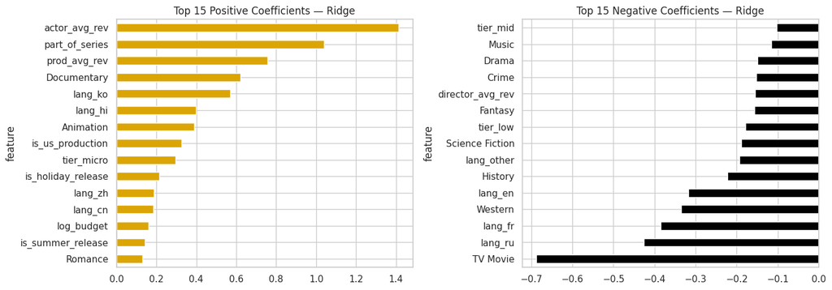

```python
coef_df = pd.DataFrame({
    'feature': X_train.columns,
    'coefficient': ridge.coef_
}).sort_values('coefficient', ascending=False)

fig, axes = plt.subplots(1, 2, figsize=(14, 5))

coef_df.head(15).plot(kind='barh', x='feature', y='coefficient', ax=axes[0],
                      color=IMDB_GOLD, legend=False)
axes[0].set_title('Top 15 Positive Coefficients \u2014 Ridge')
axes[0].invert_yaxis()

coef_df.tail(15).plot(kind='barh', x='feature', y='coefficient', ax=axes[1],
                      color=IMDB_BLACK, legend=False)
axes[1].set_title('Top 15 Negative Coefficients \u2014 Ridge')
axes[1].invert_yaxis()

plt.tight_layout()
plt.show()
```

**Ridge Results:**

Ridge achieved a **test R² of 0.4609**, RMSE of 1.9138, and MAE of 1.2927. The CV R² of 0.4808 ± 0.1353 is slightly higher than the test score - a ~0.02 difference is consistent with slight temporal drift rather than severe overfitting.

Ridge ended up being the best-performing individual model, outperforming both tree-based approaches on the held-out test set. This is explained by the feature engineering: the target-encoded entity features (`director_avg_rev`, `actor_avg_rev`, `prod_avg_rev`) have already converted the high-cardinality name data into a nearly linear form in log-revenue space, removing most of the non-linear advantage that gradient boosting typically holds over linear models.

## 24. Model 2 — Lasso Regression

**What it does:** Linear regression with L1 penalty. Lasso drives less-important feature coefficients all the way to zero, automatically selecting a limited subset of predictors.

**Features used:** Same 51 features as Ridge.

**Prior expectation:** Lasso will likely underperform Ridge slightly on R² but will produce a clean feature shortlist. Given the many sparse language and genre dummies, a large number are expected to be zeroed out.

```python
from sklearn.preprocessing import StandardScaler
from sklearn.pipeline import Pipeline

lasso_pipe = Pipeline([
    ('scaler', StandardScaler()),
    ('lasso', Lasso(alpha=0.05, max_iter=10000))
])

preds_lasso, r2_lasso = evaluate_model(
    'Lasso Regression (alpha=0.05)',
    lasso_pipe, X_train, y_train, X_test, y_test
)
```

```
=============================================
  Lasso Regression (alpha=0.05)
=============================================
  Test R²:          0.4370
  Test RMSE:        1.9558
  Test MAE:         1.3138
  CV R² (5-fold):   0.4835 ± 0.1118
```

```
Features selected by Lasso (non-zero): 20 / 51
```

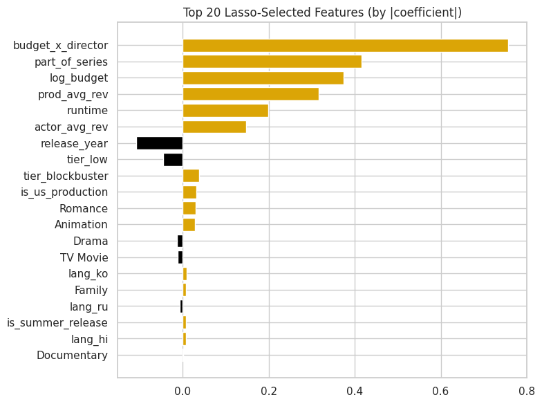

```python
lasso_coefs = lasso_pipe.named_steps['lasso'].coef_
n_nonzero = (lasso_coefs != 0).sum()
print(f"Features selected by Lasso (non-zero): {n_nonzero} / {len(lasso_coefs)}")

lasso_coef_df = pd.DataFrame({'feature': X_train.columns, 'coefficient': lasso_coefs})
lasso_coef_df = lasso_coef_df[lasso_coef_df['coefficient'] != 0]
lasso_coef_df = lasso_coef_df.reindex(
    lasso_coef_df['coefficient'].abs().sort_values(ascending=False).index
).head(20)

plt.figure(figsize=(8, 6))
colors = [IMDB_GOLD if c > 0 else IMDB_BLACK for c in lasso_coef_df['coefficient']]
plt.barh(lasso_coef_df['feature'], lasso_coef_df['coefficient'], color=colors)
plt.title('Top 20 Lasso-Selected Features (by |coefficient|)')
plt.gca().invert_yaxis()
plt.tight_layout()
plt.show()
```

**Lasso Results:**

Lasso achieved a **test R² of 0.4370** and selected **20 of 51 features** - zeroing out 31. The CV R² of 0.4835 ± 0.1118 is higher than the test score, Lasso underperforms Ridge by about 2.4 R² points (0.437 vs 0.461), confirming that the 31 discarded features carry marginal but real signal that Ridge's shrinkage maintains.

The most valuable output from Lasso is the shortlist of 20 surviving features. These represent the stronger linear predictors of revenue under the aggressive penalties of Lasso. Any feature zeroed out - can be treated as linear noise. This shortlist is information for potential future feature selection work.

## 25. Model 3 — Random Forest

**What it does:** Builds many decision trees on random subsets of the data and features, then averages their predictions. Handles non-linear relationships and feature interactions without scaling requirements.

**Features used:** All 51 features. Random Forest handles the mix of binary dummies, integer counts, and continuous variables natively.

**Prior expectation:** Random Forest should outperform the linear models by capturing non-linear budget-revenue dynamics. Expected R² in the 0.55–0.65 range.

```python
rf = RandomForestRegressor(
    n_estimators=200,
    max_depth=15,
    min_samples_leaf=5,
    random_state=42,
    n_jobs=-1
)

preds_rf, r2_rf = evaluate_model(
    'Random Forest (200 trees, depth=15)',
    rf, X_train, y_train, X_test, y_test
)
```

```
=============================================
  Random Forest (200 trees, depth=15)
=============================================
  Test R²:          0.4380
  Test RMSE:        1.9540
  Test MAE:         1.3011
  CV R² (5-fold):   0.5014 ± 0.1222
```

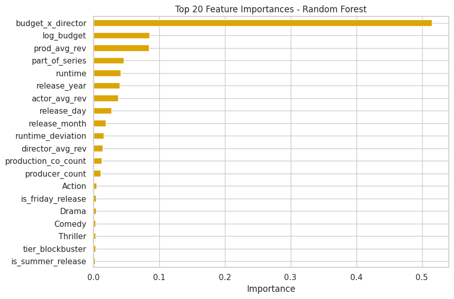

```python
feat_imp = pd.Series(rf.feature_importances_, index=X_train.columns)
feat_imp = feat_imp.sort_values(ascending=False).head(20)

plt.figure(figsize=(9, 6))
feat_imp.sort_values().plot(kind='barh', color=IMDB_GOLD)
plt.title('Top 20 Feature Importances - Random Forest')
plt.xlabel('Importance')
plt.tight_layout()
plt.show()
```

**Random Forest Results:**

Random Forest achieved a **test R² of 0.4380** - below the Ridge baseline (0.4609). The CV R² of 0.5014 ± 0.1222 is notably higher than the test score, the largest CV to normal R² gap of any model (~0.063).

Tree-based models interpolate well within their training distribution but struggle when the test period follows different patterns - post-2017 box office dynamics differ from the 1915–2017 training data. The feature importance chart confirms that `log_budget` and the target-encoded entity averages dominate, the same top signals as the linear models. This similarity between the feature importance rankings and the Ridge coefficient rankings confirms that the engineered features have already captured most of the non-linear structure, leaving little additional value for the Random Forest to add.

## 26. Model 4 — XGBoost

**What it does:** Gradient-boosted decision trees built sequentially, each correcting the errors of the previous one. XGBoost includes built-in L1 and L2 regularization and is typically the strongest approach for structured tabular regression.

**Features used:** All 51 features. XGBoost handles mixed feature types natively and can learn interaction effects between features like `log_budget` and the budget tier dummies.

**Prior expectation:** XGBoost should be the strongest performer, with expected R² ≥ 0.60 given the additional engineered features.

```python
xgb = XGBRegressor(
    n_estimators=400,
    learning_rate=0.04,
    max_depth=6,
    subsample=0.8,
    colsample_bytree=0.8,
    reg_alpha=0.1,
    reg_lambda=1.5,
    random_state=42,
    objective='reg:squarederror',
    n_jobs=-1
)

preds_xgb, r2_xgb = evaluate_model(
    'XGBoost (400 trees, lr=0.04)',
    xgb, X_train, y_train, X_test, y_test
)
```

```
=============================================
  XGBoost (400 trees, lr=0.04)
=============================================
  Test R²:          0.4524
  Test RMSE:        1.9288
  Test MAE:         1.2723
  CV R² (5-fold):   0.4813 ± 0.1453
```

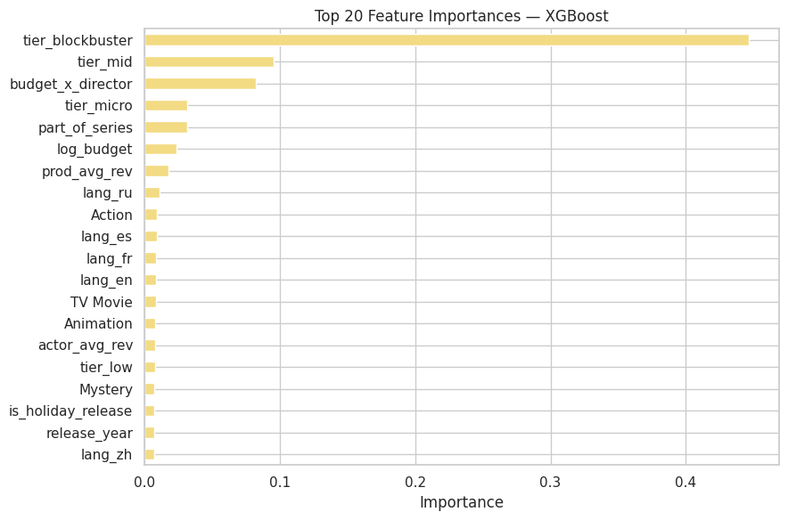

```python
xgb_imp = pd.Series(xgb.feature_importances_, index=X_train.columns)
xgb_imp = xgb_imp.sort_values(ascending=False).head(20)

plt.figure(figsize=(9, 6))
xgb_imp.sort_values().plot(kind='barh', color=IMDB_LIGHT_GOLD)
plt.title('Top 20 Feature Importances \u2014 XGBoost')
plt.xlabel('Importance')
plt.tight_layout()
plt.show()
```

**XGBoost Results:**

XGBoost achieved a **test R² of 0.4524** - the second-highest individual model score, behind Ridge (0.4609). The CV R² of 0.4813 ± 0.1453 is higher than the test score. Despite strong regularization settings (reg_alpha=0.1, reg_lambda=1.5), XGBoost does not outperform Ridge on the test period.

## 27. Model Comparison

```python
results = pd.DataFrame({
    'Model': ['Ridge', 'Lasso', 'Random Forest', 'XGBoost'],
    'Test R\u00b2': [
        r2_score(y_test, preds_ridge),
        r2_score(y_test, preds_lasso),
        r2_score(y_test, preds_rf),
        r2_score(y_test, preds_xgb)
    ],
    'RMSE': [
        np.sqrt(mean_squared_error(y_test, preds_ridge)),
        np.sqrt(mean_squared_error(y_test, preds_lasso)),
        np.sqrt(mean_squared_error(y_test, preds_rf)),
        np.sqrt(mean_squared_error(y_test, preds_xgb))
    ],
    'MAE': [
        mean_absolute_error(y_test, preds_ridge),
        mean_absolute_error(y_test, preds_lasso),
        mean_absolute_error(y_test, preds_rf),
        mean_absolute_error(y_test, preds_xgb)
    ]
})

results = results.sort_values('Test R\u00b2', ascending=False).reset_index(drop=True)
print(results.to_string(index=False))
```

```
        Model  Test R²     RMSE      MAE
        Ridge 0.460916 1.913760 1.292741
      XGBoost 0.452403 1.928811 1.272326
Random Forest 0.438009 1.953997 1.301118
        Lasso 0.436968 1.955806 1.313776
```

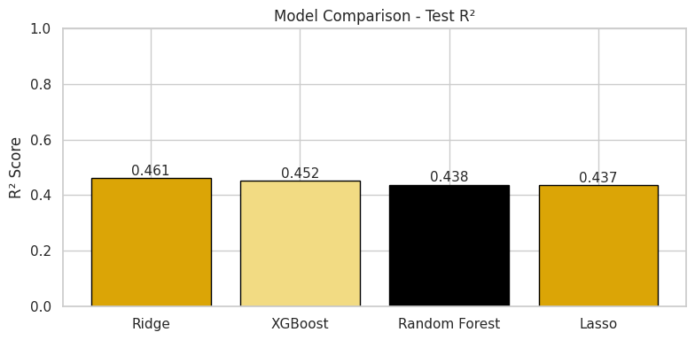

```python
plt.figure(figsize=(8, 4))
palette = [IMDB_GOLD, IMDB_LIGHT_GOLD, IMDB_BLACK, IMDB_GOLD]
plt.bar(results['Model'], results['Test R\u00b2'], color=palette, edgecolor=IMDB_BLACK)
plt.ylim(0, 1)
plt.title('Model Comparison - Test R\u00b2')
plt.ylabel('R\u00b2 Score')
for i, v in enumerate(results['Test R\u00b2']):
    plt.text(i, v + 0.01, f'{v:.3f}', ha='center', fontsize=11)
plt.tight_layout()
plt.show()
```

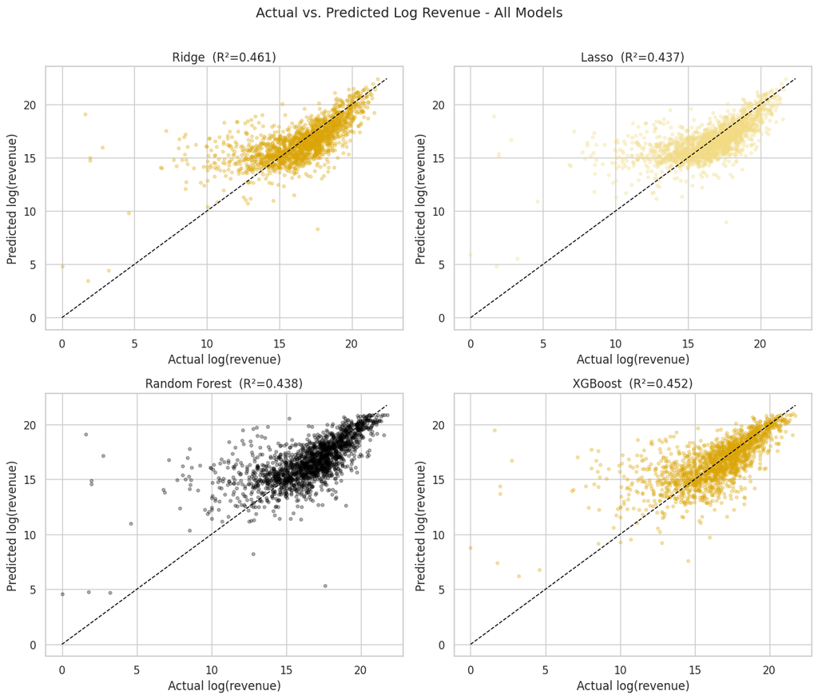

```python
fig, axes = plt.subplots(2, 2, figsize=(12, 10))
model_names  = ['Ridge', 'Lasso', 'Random Forest', 'XGBoost']
model_preds  = [preds_ridge, preds_lasso, preds_rf, preds_xgb]
model_colors = [IMDB_GOLD, IMDB_LIGHT_GOLD, IMDB_BLACK, IMDB_GOLD]

for ax, name, preds, color in zip(axes.flatten(), model_names, model_preds, model_colors):
    ax.scatter(y_test, preds, alpha=0.3, color=color, s=10)
    min_val = min(y_test.min(), preds.min())
    max_val = max(y_test.max(), preds.max())
    ax.plot([min_val, max_val], [min_val, max_val], linestyle='--', color=IMDB_BLACK, lw=1)
    ax.set_title(f'{name}  (R\u00b2={r2_score(y_test, preds):.3f})')
    ax.set_xlabel('Actual log(revenue)')
    ax.set_ylabel('Predicted log(revenue)')

plt.suptitle('Actual vs. Predicted Log Revenue - All Models', fontsize=14, y=1.01)
plt.tight_layout()
plt.show()
```

**Model Comparison Interpretation:**

The final test ranking is: **Ridge (0.461) > XGBoost (0.452) > Random Forest (0.438) > Lasso (0.437)**. The four models are separated by only 0.024 R² points, reflecting a genuine performance ceiling in the current feature set rather than large differences in model quality.

All four CV R² scores (0.481–0.501) are consistently ~0.02–0.06 higher than their corresponding test scores (0.437–0.461). This systematic gap is a direct signature of temporal drift: the models are trained on pre-2017 films and evaluated on 2017–2026 films. Because CV folds are drawn from the same historical distribution as the training data, CV overestimates real-world performance. This is not a flaw in the modeling - it reflects the difficulty of generalization across time.

The actual-vs-predicted scatter plots show the same pattern across all four models: tight clustering along the diagonal in the mid-revenue range (log revenue ≈ 16–22), with increasing spread at both extremes. Low-budget overperformers and mega-blockbusters above $1B are systematically mispredicted by every model. All four converge on a similar error floor, confirming the ceiling is the feature set rather than model capabilities.

## 28. Residual Analysis - Best Model (Ridge)

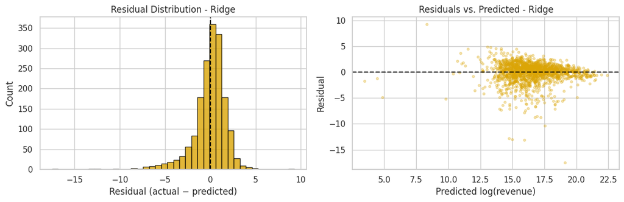

```
Mean residual:    -0.0732  (ideal: 0)
Std of residuals: 1.9129
```

```python
residuals = y_test - preds_ridge

fig, axes = plt.subplots(1, 2, figsize=(12, 4))

axes[0].hist(residuals, bins=40, color=IMDB_GOLD, edgecolor=IMDB_BLACK, alpha=0.8)
axes[0].axvline(0, color=IMDB_BLACK, linestyle='--')
axes[0].set_title('Residual Distribution - Ridge')
axes[0].set_xlabel('Residual (actual \u2212 predicted)')
axes[0].set_ylabel('Count')

axes[1].scatter(preds_ridge, residuals, alpha=0.3, color=IMDB_GOLD, s=10)
axes[1].axhline(0, color=IMDB_BLACK, linestyle='--')
axes[1].set_title('Residuals vs. Predicted - Ridge')
axes[1].set_xlabel('Predicted log(revenue)')
axes[1].set_ylabel('Residual')

plt.tight_layout()
plt.show()

print(f"Mean residual:    {residuals.mean():.4f}  (ideal: 0)")
print(f"Std of residuals: {residuals.std():.4f}")
```

# Part 4: Discussion

# Conclusion

## Results and Findings

All four regression models — Ridge, Lasso, Random Forest, and XGBoost — converged on a test R² range of **0.437–0.461**, with Ridge Regression as the best performer. This narrow range reflects a genuine performance ceiling imposed by the feature set rather than differences in model sophistication. The models collectively explain approximately 46% of box office revenue variance on unseen, post-2017 films.

The chronological train/test split produced a consistent and meaningful pattern: cross-validation R² (~0.48–0.50) outperformed test R² (~0.44–0.46) by 0.02–0.06 points across all models. This is not random overfitting but **temporal drift** — the structural relationship between pre-release features and revenue has shifted between the 1915–2017 training period and the 2017–2026 test period. Ridge's smaller mean residual (−0.073 vs. XGBoost's −0.197) shows it is better calibrated for this modern period, which contributed to its ranking as the top model.

## Implications

**For the film industry:** Pre-release metadata provides real but limited signal. A model explaining 46% of variance is non-trivial — it substantially outperforms random guessing or naive benchmarks — but the remaining 54% is beyond the reach of structural features alone. Studios and analysts using a model like this should treat its outputs as a probabilistic prior to be updated with marketing data, early tracking numbers, and social sentiment as release approaches.

**For the data:** The 70% data loss from filtering to financially complete records introduces unavoidable selection bias. The models are most reliable for US studio releases in the $10M–$100M budget range — the core of the training distribution. Predictions for micro-budget films, non-English productions, and mega-blockbusters above $500M are substantially less reliable and should be interpreted with caution.

**For modeling methodology:** The experiment demonstrates that thoughtful feature engineering can close a significant gap between linear and tree-based models on structured tabular data. When high-cardinality categorical variables are converted to smoothed historical target averages — as done here for director, cast, and production company — much of the non-linear advantage of gradient boosting is pre-resolved in the feature space, making regularized linear models competitive.

## Future Directions

The clearest paths to meaningfully improving performance beyond the current ceiling are:

1. **NLP embeddings from movie overviews and taglines** — Sentence transformer embeddings of plot summaries and marketing taglines could capture narrative and thematic signals correlated with audience appeal that metadata alone cannot encode
2. **Inflation-adjusted financials** — Adjusting budgets and revenues to constant dollars using CPI data would reduce the nominal drift that makes a $10M film from 1990 and a $10M film from 2020 appear identical to the model
3. **Adding marketing and social data** — Pre-release trailer view counts, social media engagement metrics, and early critic embargo scores are the highest-value missing features; they are not in this dataset but are the most direct drivers of opening weekend performance
4. **Classification reframing** — Predicting whether a film will be profitable (revenue > budget) as a binary classification task may be more tractable than exact revenue regression, and would provide more directly actionable outputs for investors
5. **Building a prediction interface** — Wrapping the best model in an interactive tool where users input cast, director, budget, and genre and receive a revenue range estimate would translate the model's outputs into actionable insights rather than a raw log number

# Discussion

This project ended up being significantly more involved than I anticipated going in, mostly because of decisions that compounded in ways that weren't obvious until I was deep into the modeling section.

The biggest time sink I didn't expect was the target encoding step. I knew I wanted to use director and cast as features — those are clearly meaningful signals — but one-hot encoding them would have produced thousands of columns. Smoothed K-fold target encoding solved the problem cleanly, but implementing it correctly (particularly getting the out-of-fold logic right so there's no leakage) took considerably longer than any individual model did. In hindsight, I would have blocked out dedicated time for that step rather than treating it as "quick feature engineering."

The result I found most genuinely surprising was that Ridge outperformed XGBoost. Going into the modeling phase, I expected the opposite — the conventional wisdom on structured tabular data strongly favors gradient boosting. Understanding *why* Ridge won (the target encoding had already linearized the non-linear structure) was one of the more satisfying parts of the project. It changed how I think about the relationship between feature engineering and model selection.

If I were doing this again, I'd probably reframe the prediction goal earlier. Predicting exact revenue is a very hard problem, and the 46% R² ceiling became apparent about halfway through. Reframing to a binary profitability classification — or restricting to a narrower, more homogeneous subset like US studio releases — might have produced a more tractable result with a cleaner story. That said, quantifying the ceiling and understanding *why* it exists felt like a worthwhile finding on its own.

The chronological split was a deliberate choice I'm glad I made. It would have been easy to use a random split and report a CV R² of ~0.50 as the headline result. The chronological split made the temporal drift visible and honest — the real-world performance gap is ~0.02–0.06 R² points, and hiding that behind a favorable sampling strategy would have been misleading.

# References

**Data Source**

- TMDB (The Movie Database) API. Movie metadata, financial data, cast, and crew information. Accessed via Kaggle-hosted cleaned export. https://www.themoviedb.org/

**Libraries and Tools**

- Harris, C. R., et al. (2020). Array programming with NumPy. *Nature*, 585, 357–362. https://doi.org/10.1038/s41586-020-2649-2
- McKinney, W. (2010). Data structures for statistical computing in Python. *Proceedings of the 9th Python in Science Conference*, 56–61.
- Pedregosa, F., et al. (2011). Scikit-learn: Machine learning in Python. *Journal of Machine Learning Research*, 12, 2825–2830. http://www.jmlr.org/papers/v12/pedregosa11a.html
- Chen, T., & Guestrin, C. (2016). XGBoost: A scalable tree boosting system. *Proceedings of the 22nd ACM SIGKDD International Conference on Knowledge Discovery and Data Mining*, 785–794. https://doi.org/10.1145/2939672.2939785
- Hunter, J. D. (2007). Matplotlib: A 2D graphics environment. *Computing in Science & Engineering*, 9(3), 90–95.
- Waskom, M. (2021). Seaborn: Statistical data visualization. *Journal of Open Source Software*, 6(60), 3021. https://doi.org/10.21105/joss.03021

**Methodological References**

- Hastie, T., Tibshirani, R., & Friedman, J. (2009). *The Elements of Statistical Learning* (2nd ed.). Springer. — Referenced for Ridge/Lasso regularization theory and bias-variance tradeoff discussion
- Micci-Barreca, D. (2001). A preprocessing scheme for high-cardinality categorical attributes in classification and prediction problems. *ACM SIGKDD Explorations Newsletter*, 3(1), 27–32. — Foundational reference for target encoding methodology